# Ford GoBike Share Analysis

## Preliminary Wrangling

The following analysis is based on the data available for the GoBike Share program in the San Francisco area. It is provided [here](https://www.lyft.com/bikes/bay-wheels/system-data) by Lyft. The data used below shows information about trips since 2017 including Start and End time and station, duration, rental type and bike information.

```python
# import all necessary packages and functions.
import csv
from datetime import datetime
import numpy as np
import pandas as pd
from IPython.display import display
import os
import matplotlib.pyplot as plt
import matplotlib.colors as col
import matplotlib.patches as patches
import seaborn as sb
from pandas.api.types import CategoricalDtype

%matplotlib inline
```

```python
files = os.listdir("./source_files/")

li = []

delimiter = ';'

shrtwkday = CategoricalDtype(categories=['Sun','Mon','Tue','Wed','Thu','Fri','Sat'], ordered=True)

use_cols = ['duration_sec','start_time','end_time','start_station_id','start_station_name','start_station_latitude',
            'start_station_longitude','end_station_id','end_station_name','end_station_latitude',
            'end_station_longitude','bike_id','user_type']

dtypes = {'duration_sec':'int','start_time':'str','end_time':'str','start_station_id':pd.Int64Dtype(),'start_station_name':'str',
          'start_station_latitude':'float','start_station_longitude':'float','end_station_id':pd.Int64Dtype(),
          'end_station_name':'str','end_station_latitude':'float','end_station_longitude':'float',
          'bike_id':'int','user_type':'str'}

parse_dates = ['start_time','end_time']



for file in files:
    with open("./source_files/" + file, 'rb') as f_in:
        df = pd.read_csv(f_in, compression='zip', delimiter=delimiter, usecols = use_cols, dtype=dtypes,
                         header=0, parse_dates=parse_dates, na_values=['', ' '])
        li.append(df)

trip_df = pd.concat(li, axis=0, ignore_index=True)

display(trip_df.head(5))
```

|  | duration_sec | start_time | end_time | start_station_id | start_station_name | start_station_latitude | start_station_longitude | end_station_id | end_station_name | end_station_latitude | end_station_longitude | bike_id | user_type |
| --- | --- | --- | --- | --- | --- | --- | --- | --- | --- | --- | --- | --- | --- |
| 0 | 80110 | 2017-12-31 16:57:39.654 | 2018-01-01 15:12:50.245 | 74 | Laguna St at Hayes St | 37.776435 | -122.426244 | 43 | San Francisco Public Library (Grove St at Hyde... | 37.778768 | -122.415929 | 96 | Customer |
| 1 | 78800 | 2017-12-31 15:56:34.842 | 2018-01-01 13:49:55.617 | 284 | Yerba Buena Center for the Arts (Howard St at ... | 37.784872 | -122.400876 | 96 | Dolores St at 15th St | 37.766210 | -122.426614 | 88 | Customer |
| 2 | 45768 | 2017-12-31 22:45:48.411 | 2018-01-01 11:28:36.883 | 245 | Downtown Berkeley BART | 37.870348 | -122.267764 | 245 | Downtown Berkeley BART | 37.870348 | -122.267764 | 1094 | Customer |
| 3 | 62172 | 2017-12-31 17:31:10.636 | 2018-01-01 10:47:23.531 | 60 | 8th St at Ringold St | 37.774520 | -122.409449 | 5 | Powell St BART Station (Market St at 5th St) | 37.783899 | -122.408445 | 2831 | Customer |
| 4 | 43603 | 2017-12-31 14:23:14.001 | 2018-01-01 02:29:57.571 | 239 | Bancroft Way at Telegraph Ave | 37.868813 | -122.258764 | 247 | Fulton St at Bancroft Way | 37.867789 | -122.265896 | 3167 | Subscriber |

The data is stored in multiple CSV files using a ';' as the delimiter. The fact that the data has 4 million rows is very intriguing. There is a lot of information here. The fact that trips can be traced to specific bikes is interesting in terms of asset utilization. Also the ability to see any trends related to day of week or yearly seasonality will be interesting. A deeper look would be interesting to see actual patterns that exist between stations, which station pairs are connected for example.

I will focus mainly on trends related to daily, weekly and monthly patterns. Having the start times for each rental will be key. I will also briefly look to see if there are any interesting patterns causing certain specific bikes to be used more, and thus age more. The bike ID will be useful for that investigation.

Due to the size of the data and the processing time required for the visualizations, I will take a random sample of 10% of the data for this analysis.

```python
trip_df = trip_df.sample(frac=.1)
trip_df.info()
```

```
<class 'pandas.core.frame.DataFrame'>
Int64Index: 474030 entries, 3448565 to 1276061
Data columns (total 13 columns):
duration_sec               474030 non-null int32
start_time                 474030 non-null datetime64[ns]
end_time                   474030 non-null datetime64[ns]
start_station_id           466953 non-null Int64
start_station_name         467025 non-null object
start_station_latitude     474030 non-null float64
start_station_longitude    474030 non-null float64
end_station_id             466747 non-null Int64
end_station_name           466804 non-null object
end_station_latitude       474030 non-null float64
end_station_longitude      474030 non-null float64
bike_id                    474030 non-null int32
user_type                  474030 non-null object
dtypes: Int64(2), datetime64[ns](2), float64(4), int32(2), object(3)
memory usage: 47.9+ MB
```

Here we will engineer some features from the data to create new columns representing the various attributes of the start and end times.

```python
trip_df['start_date'] = trip_df.start_time.dt.strftime('%Y-%m-%d')
trip_df['start_year'] = trip_df.start_time.dt.strftime('%Y').astype(int)
trip_df['start_month'] = trip_df.start_time.dt.strftime('%m').astype(int)
trip_df['start_hour'] = trip_df.start_time.dt.strftime('%H').astype(int)
trip_df['start_weekday'] = trip_df.start_time.dt.strftime('%a').astype(shrtwkday)

trip_df['end_date'] = trip_df.end_time.dt.strftime('%Y-%m-%d')
trip_df['end_year'] = trip_df.end_time.dt.strftime('%Y').astype(int)
trip_df['end_month'] = trip_df.end_time.dt.strftime('%m').astype(int)
trip_df['end_hour'] = trip_df.end_time.dt.strftime('%H').astype(int)
trip_df['end_weekday'] = trip_df.end_time.dt.strftime('%a').astype(shrtwkday)

trip_df['start_date'] = pd.to_datetime(trip_df['start_date'], format = "%Y-%m-%d")
trip_df['end_date'] = pd.to_datetime(trip_df['start_date'], format = "%Y-%m-%d")
```

```python
trip_df.info()
```

```
<class 'pandas.core.frame.DataFrame'>
Int64Index: 474030 entries, 3448565 to 1276061
Data columns (total 23 columns):
duration_sec               474030 non-null int32
start_time                 474030 non-null datetime64[ns]
end_time                   474030 non-null datetime64[ns]
start_station_id           466953 non-null Int64
start_station_name         467025 non-null object
start_station_latitude     474030 non-null float64
start_station_longitude    474030 non-null float64
end_station_id             466747 non-null Int64
end_station_name           466804 non-null object
end_station_latitude       474030 non-null float64
end_station_longitude      474030 non-null float64
bike_id                    474030 non-null int32
user_type                  474030 non-null object
start_date                 474030 non-null datetime64[ns]
start_year                 474030 non-null int32
start_month                474030 non-null int32
start_hour                 474030 non-null int32
start_weekday              474030 non-null category
end_date                   474030 non-null datetime64[ns]
end_year                   474030 non-null int32
end_month                  474030 non-null int32
end_hour                   474030 non-null int32
end_weekday                474030 non-null category
dtypes: Int64(2), category(2), datetime64[ns](4), float64(4), int32(8), object(3)
memory usage: 66.9+ MB
```

## Univariate Exploration

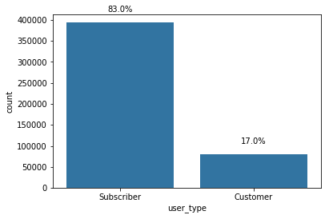

```python
# Shape[0] is the number of rows; Shape[1] is the number of columns
base_color = sb.color_palette()[0]

n_trips = trip_df.shape[0]

user_counts = trip_df['user_type'].value_counts()
user_type_order = trip_df['user_type'].value_counts().index

max_user_count = user_counts[0]
max_prop = max_user_count / n_trips
tick_props = np.arange(0, max_prop+0.2, 0.2)
tick_names = ['{:0.2f}'.format(v) for v in tick_props]


sb.countplot(data = trip_df, x = 'user_type', color = base_color,
            order = user_type_order);

for i in range(user_counts.shape[0]):
    count = user_counts[i]
    pct_string = '{:0.1f}%'.format(100*count/n_trips)
    plt.text(i, count+25000, pct_string, ha = 'center');
```

Clearly the model is doing a good job of attracting subscribers to the product. Only 17% of the trips in the sampled data were taken by non-subscribers and the raw number demonstrate a large number of overall trips within the system.

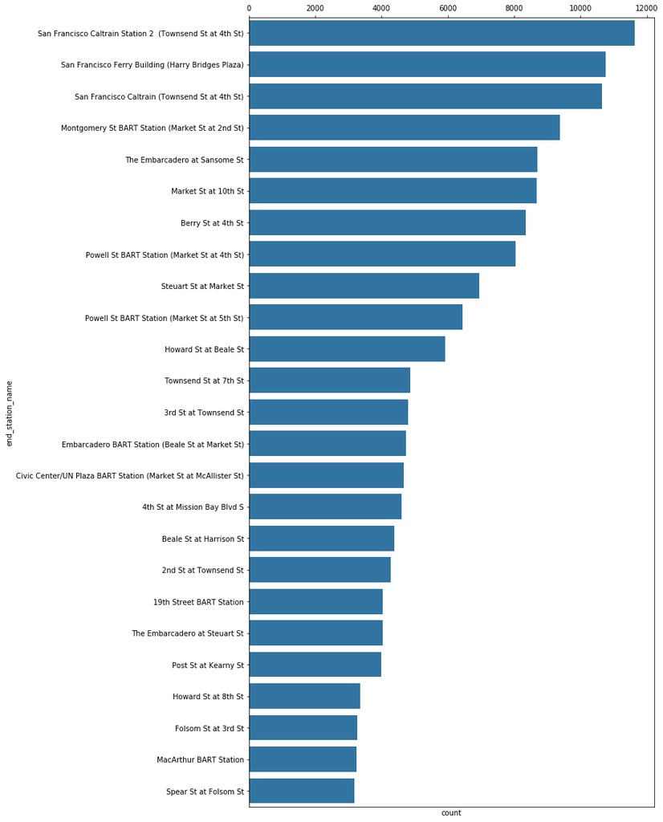

```python
plt.figure(figsize = [10, 20])

#fig, ax = plt.subplots();


end_station_order = trip_df['end_station_name'].value_counts().index

sb.countplot(data = trip_df, y = 'end_station_name', color = base_color,
            order = end_station_order[:25]);

plt.xticks(rotation = 90);
plt.gca().xaxis.set_ticks_position('top')

plt.show()
```

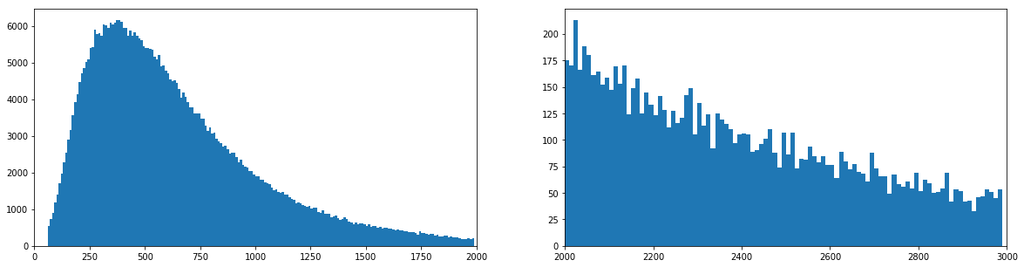

```python
plt.figure(figsize = [20, 5])

plt.subplot(1,2,1)
bins = np.arange(0,2000,10)
plt.hist(data = trip_df, x = "duration_sec", bins = bins);
plt.xlim((0,2000))

plt.subplot(1,2,2)
bins = np.arange(2000,3000,10)
plt.hist(data = trip_df, x = "duration_sec", bins = bins);
plt.xlim((2000,3000));
```

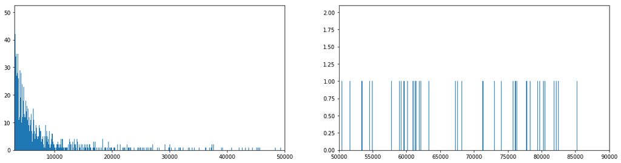

```python
plt.figure(figsize = [20, 5])

plt.subplot(1,2,1)
bins = np.arange(3000,50000,10)
plt.hist(data = trip_df, x = "duration_sec", bins = bins);
plt.xlim((3000,50000))

plt.subplot(1,2,2)
bins = np.arange(50000,90000,10)
plt.hist(data = trip_df, x = "duration_sec", bins = bins);
plt.xlim((50000,90000));
```

Plotting histogram of the trip durations, you can see the vast majority of the rentals last under 1000 seconds, but the tail is very long, with the longest rentals lasting 24 hours. Because the data in the tail becomes so small, this histogram was faceted into 4 sections to look for anomalous patterns in the tail. None are noted.

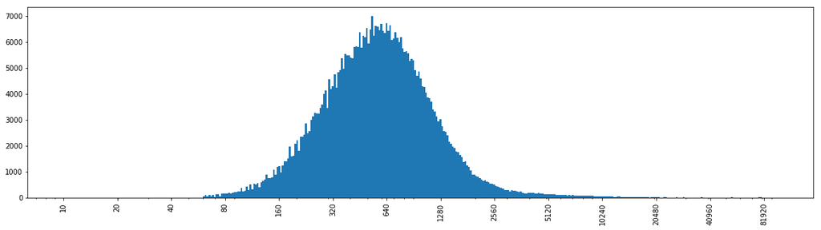

```python
plt.figure(figsize = [20, 5])

bins = 10 ** np.arange(1,5,.01)
#ticks = np.logspace(1,5,10, dtype='int')
ticks = [10, 20, 40, 80, 160, 320, 640, 1280, 2560, 5120, 10240, 20480, 40960, 81920]
labels = ['{}'.format(v) for v in ticks]

plt.hist(data = trip_df, x = "duration_sec", bins = bins);
plt.xscale('log');
plt.xticks(ticks, labels, rotation='vertical');
```

To see the entire distribution on one chart, and in doing so attempt to confirm the assessment that there are no anomalies across the full range of values for the duration, a log transformation is used. As demonstrated in the faceted charts, no anomalous information is uncovered. The resulting log-normal curve is a rational result given the data.

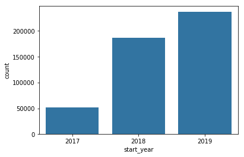

```python
sb.countplot(data = trip_df, x = 'start_year', color = base_color);
```

The nmbers indicated in this data sample demonstrate strong year over year growth.

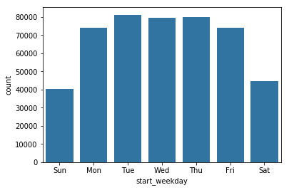

```python
sb.countplot(data = trip_df, x = 'start_weekday', color = base_color);
```

As expected, volumes drop on the weekends. It is interesting that volumes on Sunday are comparable to the volumes on Saturday. I would have expected a more dramatic difference between the days.

The duration_sec veriable is very right skewed. This makes perfect sense, because it is reasonable that with the possibility of a full-day rental (86,400 seconds) and the most likely rental being for a commute or sight seeing (which would not last near that long) that the data would be mostly grouped in the 1 hour or less interval. Performing a log transformation, I was able to visualize all of the data on one chart to see that there were no obvious abnormalities.

## Bivariate Exploration

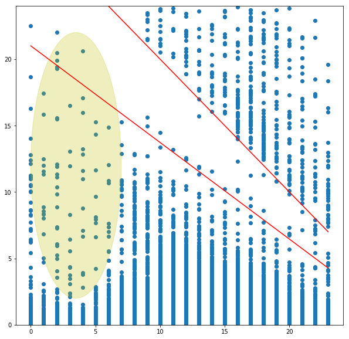

```python
plt.figure(figsize = [10, 10]) # larger figure size for subplots
plt.scatter(data = trip_df, x = 'start_hour', y = trip_df['duration_sec'] / 3600);
ax = plt.gca()
ax.set_ylim(0,24)

cir = patches.Ellipse((3.5,12),7,20, color='y', alpha=0.25);
ax.add_patch(cir);

x = np.array(range(0,24))
y = -(8 / 11) * x + 21
plt.plot(x, y, color='r')

y = -x + 30
plt.plot(x, y, color='r');
```

This chart I initialy found very interesting. The very noticeable gap pattern confounded me at first. But then I referenced the actual subscriber agreement on the Lyft website and saw that a bike could not be rented more than 24 hours and, at that point, would be marked as stolen. This would end the current trip reservation. This eliminates any carryover rentals that might add more variability in the length of time a rental might last.

Any trip that starts at the time along the x axis, and lasts the length of time along the y axis, obviously ended y hours after the time represented by x. Doing the math, this would mean the rental with a dot in that gap ended between the hours of approximately 1am to 5am for trips starting around 3pm and narrowing to a window of around 4am to 6am for trips beginning at 11pm. Note that the additions of the lines is arbitrary and therefore these time windows are imprecise. However, it still makes sense that very few reservations would end during these windows.

The sparsness of trips within the yellow ellipse is also explainable, as these represent trips that started between midnight and 6am and lasted more than just a short while.

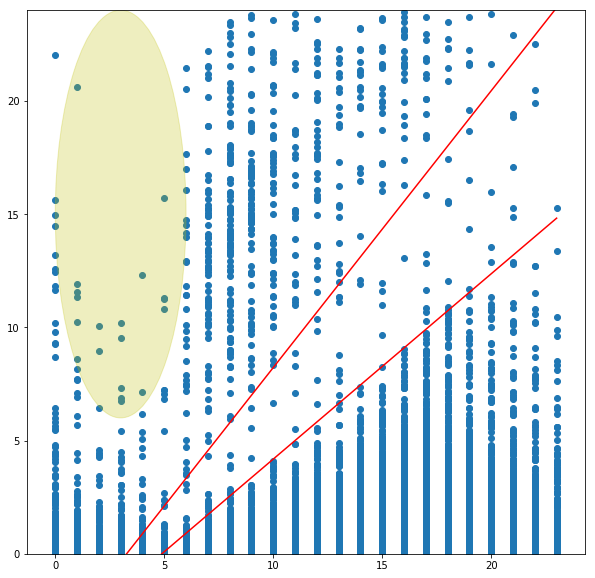

```python
fig = plt.figure(figsize = [10, 10]) # larger figure size for subplots

ax = plt.gca()
ax.set_ylim(0,24)

x = np.array(range(0,24))
y = (11 / 9) * x - 4
plt.plot(x, y, color='r')

y = (9 / 11) * x - 4
plt.plot(x, y, color='r');



plt.scatter(data = trip_df, x = 'end_hour', y = trip_df['duration_sec'] / 3600)


cir = patches.Ellipse((3,15),6,18, color='y', alpha=0.25);
ax.add_patch(cir);
```

Plotting a similar chart using the end_hour column, the phenomenon exists as well, though not quite as pronounced. The gap represents rentals that started y number of hours before the time on the x axis, so selecting 3pm, those rentals within the gap would have started from approximately 8 hours prior (7am) to around 15 hours prior (midnight). This is same area represented in the yellow ellipse from the prior graph. And the yellow ellipse in this graph highlights an area in which a rental would have started ended after midnight and before 6am, and specifically those that also started 6-24 hours earlier.

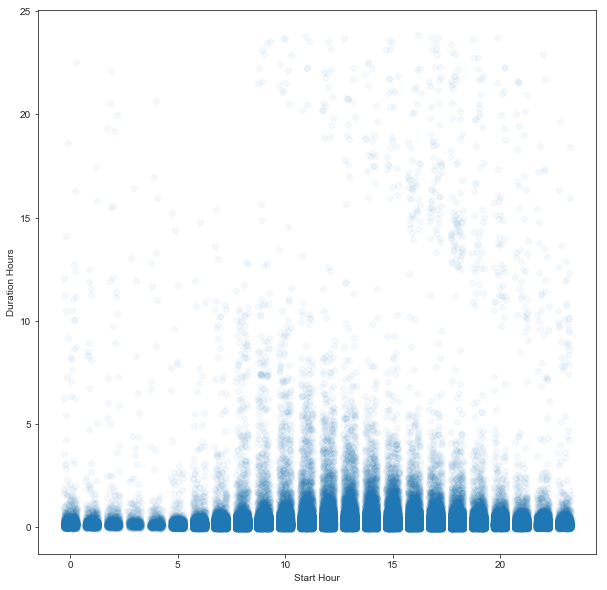

```python
plt.figure(figsize = [10, 10]) # larger figure size for subplots


sb.set_style('whitegrid')
sb.set_style("ticks", {"xtick.major.size": 20, "ytick.major.size": 1})

sb.regplot(data = trip_df, x = 'start_hour', y = trip_df['duration_sec'] / 3600, fit_reg = False,
           x_jitter = 0.3, y_jitter = 0.1, scatter_kws = {'alpha' : 1/25})

plt.xlabel("Start Hour")
plt.ylabel("Duration Hours")
plt.xticks(np.arange(0,24,5));
```

Adding a small amount of jitter and some significant transparency, it becomes clear that what looked like evenly spaced data on the previous charts is very heavily weighted toward the low end of the duration scale with the vast majority of rentals falling during the daylight hours and lasting longer, and a smaller number beginning into the late hours of the night and early hours of the morning, with those trips primarily being quite brief.

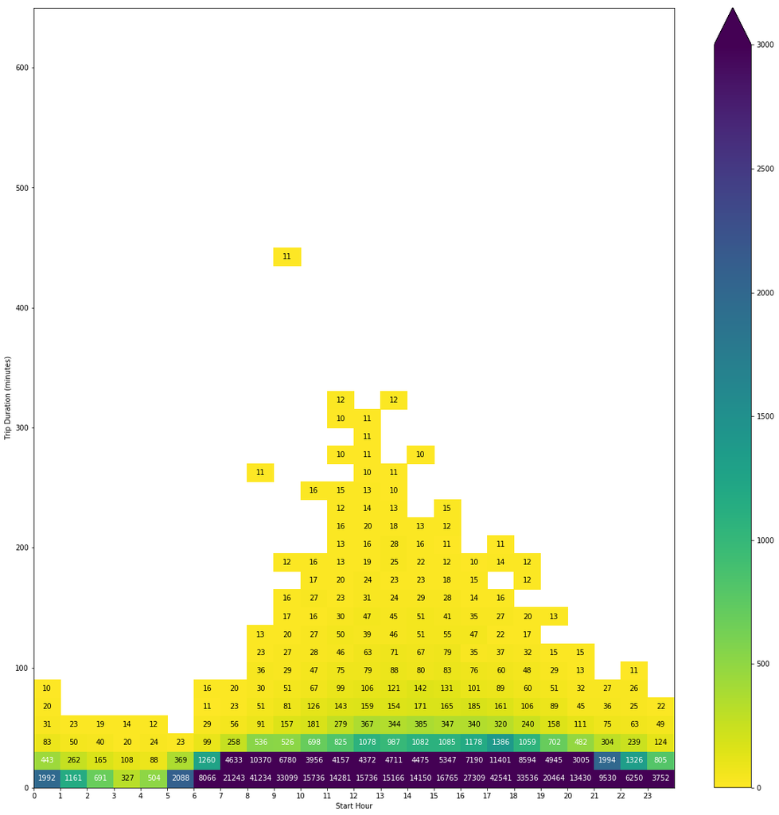

```python
bins_x = np.arange(0, 25, 1)
bins_y = np.arange(0, 600, 15)

fig = plt.figure(figsize = [20, 20]) # larger figure size for subplots

fig.subplots()

#plt.subplot(1,2,1)

h2d = plt.hist2d(data = trip_df, x = trip_df['start_hour'], y = trip_df['duration_sec'] / 60, cmin = 10,
          cmap = 'viridis_r', bins = [bins_x, bins_y],  vmin=0, vmax=3000);

plt.colorbar(extend='max', spacing='proportional')

ax = plt.gca()
ax.set_ylim([0,650])
plt.xlabel('Start Hour')
plt.ylabel('Trip Duration (minutes)')

ax.set_yticklabels = (["{} ({:.2} hours)".format(y, y / 60) for y in bins_y])
plt.xticks(bins_x[:len(bins_x)-1])

counts = h2d[0]

# loop through the cell counts and add text annotations for each
for i in range(counts.shape[0]):
    for j in range(counts.shape[1]):
        c = counts[i,j]
        if c >= 430: # increase visibility on darkest cells
            plt.text(bins_x[i]+0.5, bins_y[j]+7.5, int(c),
                     ha = 'center', va = 'center', color = 'white')
        elif c > 0:
            plt.text(bins_x[i]+0.5, bins_y[j]+7.5, int(c),
                     ha = 'center', va = 'center', color = 'black')
```

Taking a more precise look at the trips contained in the now darkened area of the previous graph, we see the scale of the disparity between those trips during the daylight hours and those after around 8pm and before 7am. In fact, there are so many trips represented in just the bottom row of the heat map, a deeper dive into that window of time is warranted to look for any unexpected patterns.

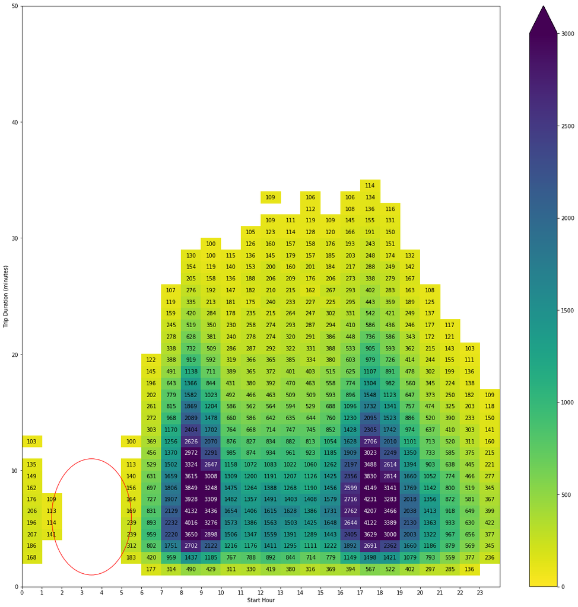

```python
bins_x = np.arange(0, 25, 1)
bins_y = np.arange(0, 100, 1)

fig = plt.figure(figsize = [20, 20]) # larger figure size for subplots

fig.subplots()

#plt.subplot(1,2,1)

h2d = plt.hist2d(data = trip_df, x = trip_df['start_hour'], y = trip_df['duration_sec'] / 60, cmin = 100,
          cmap = 'viridis_r', bins = [bins_x, bins_y],  vmin=0, vmax=3000);

plt.colorbar(extend='max', spacing='uniform')

ax = plt.gca()
ax.set_ylim([0,50])
plt.xlabel('Start Hour')
plt.ylabel('Trip Duration (minutes)')
ax.set_yticklabels = (["{} ({:.2} hours)".format(y, y / 60) for y in bins_y])
plt.xticks(bins_x[:len(bins_x)-1])

cir = patches.Ellipse((3.5,6),4,10, color='r', fill=False);
ax.add_patch(cir);

counts = h2d[0]

# loop through the cell counts and add text annotations for each
for i in range(counts.shape[0]):
    for j in range(counts.shape[1]):
        c = counts[i,j]
        if c >= 2500: # increase visibility on darkest cells
            plt.text(bins_x[i]+0.5, bins_y[j]+0.5, int(c),
                     ha = 'center', va = 'center', color = 'white')
        elif c > 0:
            plt.text(bins_x[i]+0.5, bins_y[j]+0.5, int(c),
                     ha = 'center', va = 'center', color = 'black')
```

And here, finally we have a heatmap of trips lasting less than 50 minutes in duration by hour of the day. No huge surprise, however some useful data found in this chart. With the minimim count required to appear on the map set at 100, we see that nothing appears at all with start times between 2am and 5am. And now the glob of data at the bottom of the previous charts starts to take some nice, predictable shape with some meaningful data quantified within. The number of trips heats up during the traditional commuting windows, with durations of the trips heating up in the 4-15 minute range. This data would tell business owners a lot about the characteristics of their riders.

## Multivariate Exploration

```python
def heatplot(data, title, ylim = 50, cmin = 20,cmax = 10000,vmax = 500,bins_x = np.arange(0, 25, 1),bins_y = np.arange(0, 100, 1),colsplit = 200):

    h2d = plt.hist2d(data = data, x = data['start_hour'], y = data['duration_sec'] / 60, cmin = cmin,
              cmax = cmax, cmap = 'viridis_r', bins = [bins_x, bins_y],  vmin=0, vmax=vmax);

    plt.colorbar(extend='max', spacing='uniform')

    ax = plt.gca()
    ax.set_ylim([0,ylim])
    plt.xlabel('Start Hour')
    plt.ylabel('Trip Duration (minutes)')
    axes.set_yticks(bins_y)
    axes.set_yticklabels = (["{} ({:.2} hours)".format(y, y / 60) for y in bins_y])
    plt.xticks(bins_x[:len(bins_x)-1])
    plt.title(title)

    counts = h2d[0]

    # loop through the cell counts and add text annotations for each
    for i in range(counts.shape[0]):
        for j in range(counts.shape[1]):
            c = counts[i,j]
            if c >= colsplit: # increase visibility on darkest cells
                plt.text(bins_x[i]+0.5, bins_y[j]+0.5, int(c),
                         ha = 'center', va = 'center', color = 'white')
            elif c > 0:
                plt.text(bins_x[i]+0.5, bins_y[j]+0.5, int(c),
                         ha = 'center', va = 'center', color = 'black')
    return()
```

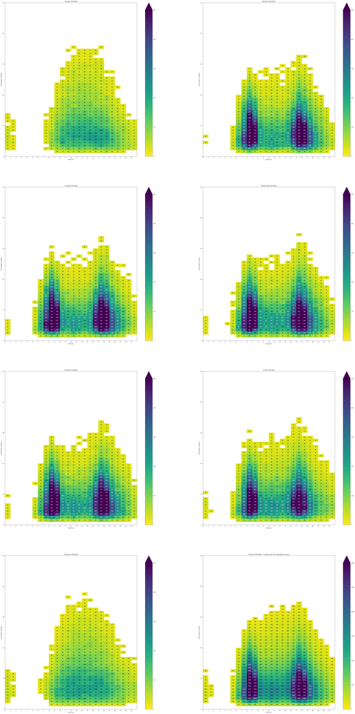

```python
fig = plt.figure(figsize = [50,100]) # larger figure size for subplots

fig.subplots(4,2)

plt.subplot(4,2,1)

heatplot(trip_df[trip_df.start_weekday == 'Sun'],title = 'Sunday Heat Map', colsplit=300);

plt.subplot(4,2,2)

heatplot(trip_df[trip_df.start_weekday == 'Mon'], title = 'Monday Heat Map');

plt.subplot(4,2,3)

heatplot(trip_df[trip_df.start_weekday == 'Tue'], title = 'Tuesday Heat Map');

plt.subplot(4,2,4)

heatplot(trip_df[trip_df.start_weekday == 'Wed'], title = 'Wednesday Heat Map');

plt.subplot(4,2,5)

heatplot(trip_df[trip_df.start_weekday == 'Thu'], title = 'Thursday Heat Map');

plt.subplot(4,2,6)

heatplot(trip_df[trip_df.start_weekday == 'Fri'], title = 'Friday Heat Map');

plt.subplot(4,2,7)

heatplot(trip_df[trip_df.start_weekday == 'Sat'], title = 'Saturday Heat Map', colsplit=300);

plt.subplot(4,2,8)

heatplot(trip_df, title = 'All Days Heat Map (* Colorbar and cmin changed for scale)', ylim=50, vmax=3000, cmin=100, cmax=100000, colsplit=2000);
```

Using faceting, these charts break up the previous heatmap into separate heatmaps for each weekday (and a final repeat of the previous chart), adding a third variable into the visualization. Two things are made clear from this exercise. First, the patterns in the weekend days is broken out from weekdays giving some insight into how those days differ from weekdays. And second, it shows a tremendously high degree of consistency from weekday to weekday, almost down to the 10s of riders in each cell. This suggests that, not only is the usage consistent, but very likely the specific riders using the bikes during the peak periods are highly consistent. Not too surprising since most riders in the system are subscribers and the most likely riders to become subscribers are those who have consistent use and those riders likely commuters, the very consumer type the product is aiming to target.

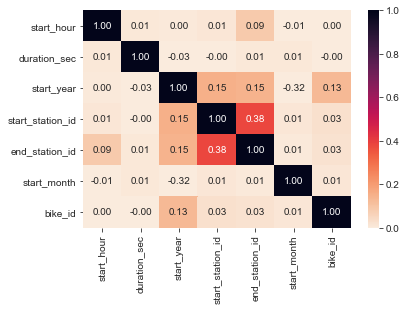

```python
trip_stats = ['start_hour','duration_sec','start_year','start_station_id','end_station_id','start_month','bike_id']
sb.heatmap(trip_df[trip_stats].corr(), cmap = 'rocket_r', annot=True, fmt = '.2f', vmin=0);
```

Using a heatmap to compare the correlation of many variables to other variables, an area for further (future) exploration is identified: the correlation between start and end station. Because the majority of rides are short in duration, the geographical radius of where a rider can reach within these durations would explain why a higher degree of correlation exists between these data points. However, understanding even within this correlation whether specific pairs of stations were even more highly correlated may identify information useful for logistics, or perhaps if there are unexpected correlations between stations that are significantly far in distance, it might suggest an opportunity for new products like motorized options.

### Talk about some of the relationships you observed in this part of the investigation. Were there features that strengthened each other in terms of looking at your feature(s) of interest?

It was interesting to be able to quantify rush hour volumes and see how the rides were spread on weekends. Nothing noteworthy was noted in terms of strengthening each other. This multivariate analysis mostly provided more detailed information about the features already selected.

### Were there any interesting or surprising interactions between features?

The high level of consistency between the ride durations and time of day when compared across weekdays was interesting in that it seems to prove certain things regarding the characteristics, and consistency, of the riders through the week.